# Loan Default Prediction

Swetha Ramanadham

30/01/2020

### Objective :

```
  To predict the risk of Default by the customer, using the given credit data for a german firm.
```

Reading the Data

```r
credit = read.csv("C:\\Users\\R swetha\\Desktop\\Model Interpretation\\germancredit.csv")

colnames(credit)
```

```
##  [1] "Default_"        "checkingstatus1" "duration"        "history"
##  [5] "purpose"         "amount"          "savings"         "employ"
##  [9] "installment"     "status"          "others"          "residence"
## [13] "property"        "age"             "otherplans"      "housing"
## [17] "cards"           "job"             "liable"          "tele"
## [21] "foreign_"
```

```r
categorical_cols<-names(Filter(is.factor,credit))
categorical_cols
```

```
##  [1] "checkingstatus1" "history"         "purpose"         "savings"
##  [5] "employ"          "status"          "others"          "property"
##  [9] "otherplans"      "housing"         "job"             "tele"
## [13] "foreign_"
```

```r
numerical_cols<-names(Filter(is.numeric,credit))
numerical_cols
```

```
## [1] "Default_"    "duration"    "amount"      "installment" "residence"
## [6] "age"         "cards"       "liable"
```

### Get a basic understanding of the dataset

```r
dim(credit)
```

```
## [1] 1000   21
```

```r
str(credit)
```

```
## 'data.frame':    1000 obs. of  21 variables:
##  $ Default_       : int  0 1 0 0 1 0 0 0 0 1 ...
##  $ checkingstatus1: Factor w/ 4 levels "A11","A12","A13",..: 1 2 4 1 1 4 4 2 4 2 ...
##  $ duration       : int  6 48 12 42 24 36 24 36 12 30 ...
##  $ history        : Factor w/ 5 levels "A30","A31","A32",..: 5 3 5 3 4 3 3 3 3 5 ...
##  $ purpose        : Factor w/ 10 levels "A40","A41","A410",..: 5 5 8 4 1 8 4 2 5 1 ...
##  $ amount         : int  1169 5951 2096 7882 4870 9055 2835 6948 3059 5234 ...
##  $ savings        : Factor w/ 5 levels "A61","A62","A63",..: 5 1 1 1 1 5 3 1 4 1 ...
##  $ employ         : Factor w/ 5 levels "A71","A72","A73",..: 5 3 4 4 3 3 5 3 4 1 ...
##  $ installment    : int  4 2 2 2 3 2 3 2 2 4 ...
##  $ status         : Factor w/ 4 levels "A91","A92","A93",..: 3 2 3 3 3 3 3 3 1 4 ...
##  $ others         : Factor w/ 3 levels "A101","A102",..: 1 1 1 3 1 1 1 1 1 1 ...
##  $ residence      : int  4 2 3 4 4 4 4 2 4 2 ...
##  $ property       : Factor w/ 4 levels "A121","A122",..: 1 1 1 2 4 4 2 3 1 3 ...
##  $ age            : int  67 22 49 45 53 35 53 35 61 28 ...
##  $ otherplans     : Factor w/ 3 levels "A141","A142",..: 3 3 3 3 3 3 3 3 3 3 ...
##  $ housing        : Factor w/ 3 levels "A151","A152",..: 2 2 2 3 3 3 2 1 2 2 ...
##  $ cards          : int  2 1 1 1 2 1 1 1 1 2 ...
##  $ job            : Factor w/ 4 levels "A171","A172",..: 3 3 2 3 3 2 3 4 2 4 ...
##  $ liable         : int  1 1 2 2 2 2 1 1 1 1 ...
##  $ tele           : Factor w/ 2 levels "A191","A192": 2 1 1 1 1 2 1 2 1 1 ...
##  $ foreign_       : Factor w/ 2 levels "A201","A202": 1 1 1 1 1 1 1 1 1 1 ...
```

```r
table(credit$Default_)
```

```
##
##   0   1
## 700 300
```

As we can see the data is highly imbalanced

### BIVARIATE ANALYSIS

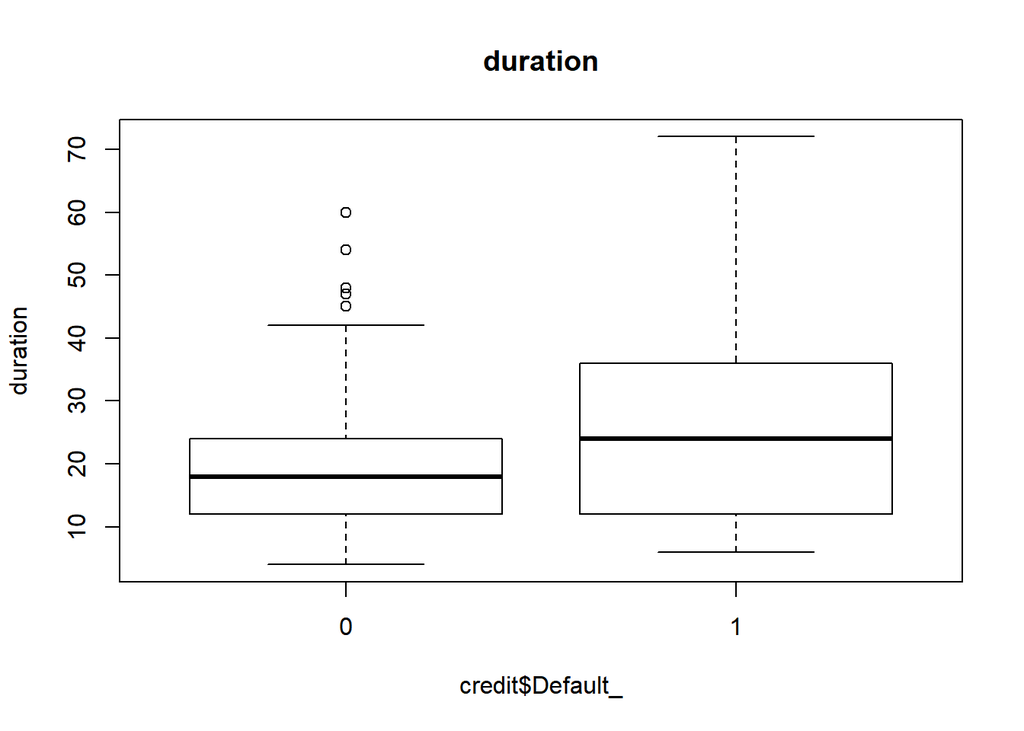

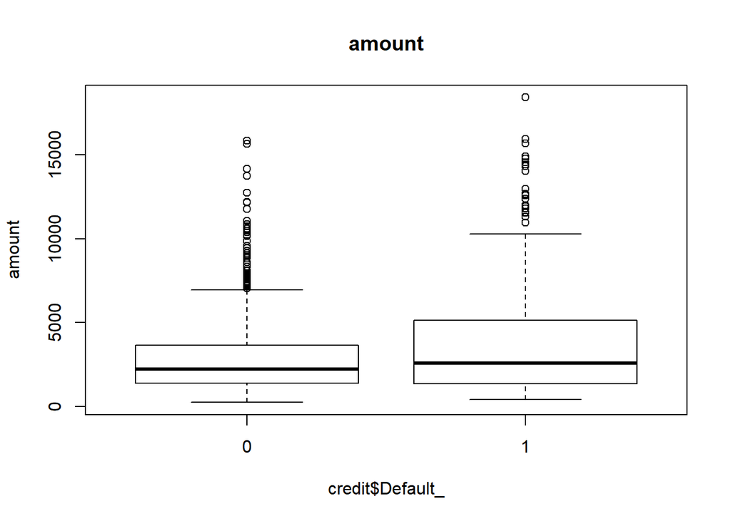

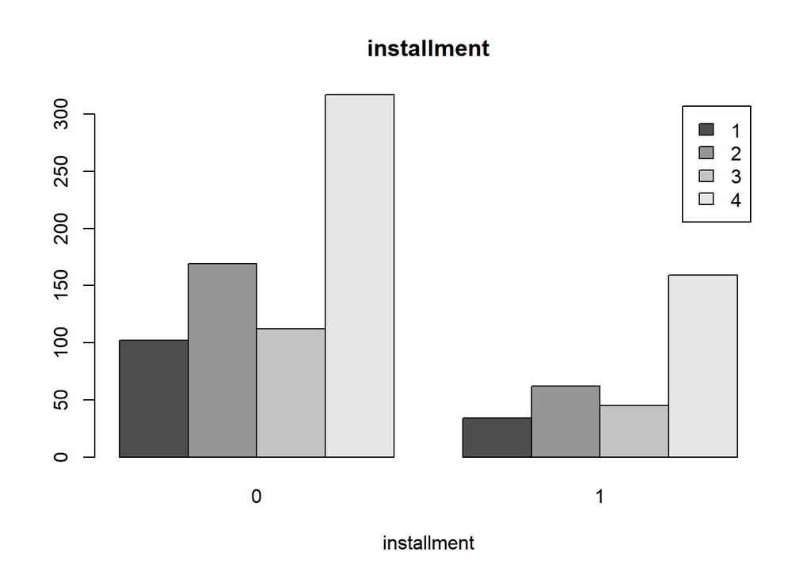

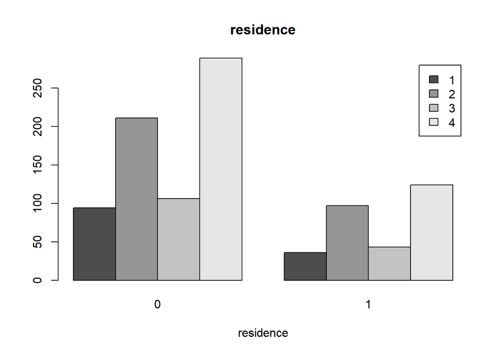

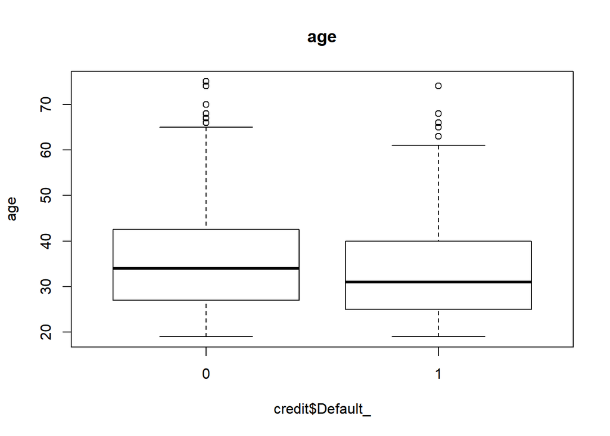

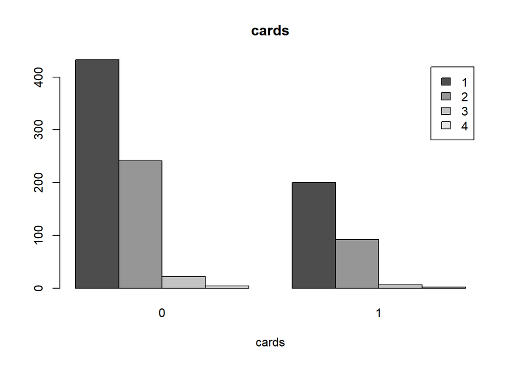

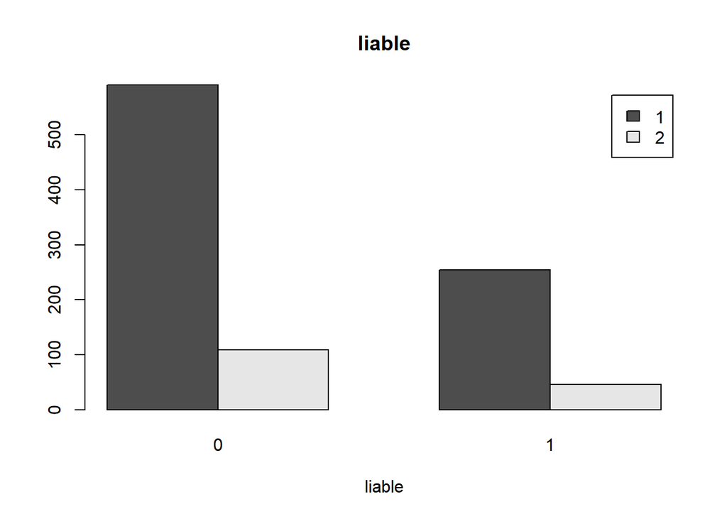

```r
#Side-by-side Boxplots for numerical variables
for(i in 2:ncol(credit))
{
  if(is.numeric(credit[,i]))
  {
    if(length(unique(credit[,i])) > 10)
    {
      boxplot(credit[,i] ~ credit$Default_, main = names(credit)[i], ylab = names(credit)[i])
    }

    else if(length(unique(credit[,i])) < 10)
    {
      barplot(table(credit[,i], credit$Default_), main=names(credit)[i],
              xlab = names(credit)[i], beside = T, legend = rownames(table(credit[,i])))
    }
  }
}
```

### Generating WOE value for all the categorical variables

```
##   CAT GOODS BADS TOTAL      PCT_G      PCT_B         WOE           IV
## 1 A30    25   15    40 0.08333333 0.02142857  1.35812348 0.0840743109
## 2 A31    28   21    49 0.09333333 0.03000000  1.13497993 0.0718820624
## 3 A32   169  361   530 0.56333333 0.51571429  0.08831862 0.0042056484
## 4 A33    28   60    88 0.09333333 0.08571429  0.08515781 0.0006488214
## 5 A34    50  243   293 0.16666667 0.34714286 -0.73374058 0.1324227042
```

### Re grouping the levels of categorical variables based on WOE

```r
library(InformationValue)
#re-level the credit history and a few other variables based on similar woe values
credit2 = credit


#VARIABLE: Credit history
credit2$history = factor(credit$history, levels=c("A30","A31","A32","A33","A34"))
levels(credit2$history) = c("good","good","poor","poor","terrible")



#VARIABLE: Purpose
credit2$purpose = factor(credit$purpose, levels=c("A41","A48","A43","A42","A44","A49","A45","A40","A410","A46"))
levels(credit2$purpose) = c("Re-training","Used-car","Radio TV", rep("FurnitureandDomesticapp",2),
                            rep("BusinessorRepairs",2), "NewCar", rep("EducationandOthers",2))   #[Check the no. of levels]

#VARIABLE: status
credit2$status = factor(credit$status, levels=c("A91","A92","A93","A94"))
levels(credit2$status) = c("male divorced","female divorced",rep("male single-married",2))

#VARIABLE: others
credit2$others = factor(credit$others, levels=c("A101","A102","A103"))
levels(credit2$others) = c("none","co-applicant","guarantor")

#VARIABLE: property
credit2$property = factor(credit$property, levels=c("A121","A122","A123","A124"))
levels(credit2$property) = c("RealEstate",rep("lifeInsurance",2),"NoProperty")


#VARIABLE: otherplans
credit2$otherplans = factor(credit$otherplans, levels=c("A141","A142","A143"))
levels(credit2$otherplans) = c(rep("bank and stores",2),"none")

#VARIABLE: housing
credit2$housing = factor(credit$housing, levels=c("A151","A152","A153"))
levels(credit2$housing) = c("rent","own","free")


#VARIABLE: job
credit2$job = factor(credit$job, levels=c("A171","A172","A173","A174"))
levels(credit2$job) = c("unskilled Non-resident","unskilled Resident","skilled","self-employed")

#VARIABLE: tele
credit2$tele = factor(credit$tele, levels=c("A191","A192"))
levels(credit2$tele) = c("not registered","registered")

#VARIABLE: foreign_
credit2$foreign_ = factor(credit$foreign_, levels=c("A201","A202"))
levels(credit2$foreign_) = c("Yes","no")
```

### Using IV to understand the importance of the categorical variables

```r
library(InformationValue)
library(Information)
for(i in 2:ncol(credit2))
{
  if(is.factor(credit2[,i]))
  {
    varname = names(credit2)[i]

    print(varname)
    print(IV(X=credit2[,varname], Y=credit2$Default_))

  }
}
```

```
## [1] "checkingstatus1"
## [1] 0.6660115
## attr(,"howgood")
## [1] "Highly Predictive"
## [1] "history"
## [1] 0.2918291
## attr(,"howgood")
## [1] "Highly Predictive"
## [1] "purpose"
## [1] 0.1689948
## attr(,"howgood")
## [1] "Highly Predictive"
## [1] "savings"
## [1] 0.1960096
## attr(,"howgood")
```

[output cut: 37 more lines]

### Using IV to understand the importance of the numerical variables

```r
IV <- create_infotables(data=credit, y="Default_", bins=10, parallel=FALSE)
IV_Value = data.frame(IV$Summary)
IV_Value
```

```
##           Variable           IV
## 1  checkingstatus1 6.660115e-01
## 3          history 2.932335e-01
## 2         duration 2.778772e-01
## 6          savings 1.960096e-01
## 4          purpose 1.691951e-01
## 13             age 1.212277e-01
## 12        property 1.126383e-01
## 5           amount 1.117618e-01
## 7           employ 8.643363e-02
## 15         housing 8.329343e-02
## 14      otherplans 5.761454e-02
## 9           status 4.467068e-02
## 20        foreign_ 4.387741e-02
## 10          others 3.201932e-02
## 8      installment 2.632209e-02
## 16           cards 1.008356e-02
## 17             job 8.762766e-03
## 19            tele 6.377605e-03
## 11       residence 3.588773e-03
## 18          liable 4.339223e-05
```

### Train-Test Split

```r
library(caTools)
set.seed(88)
split <- sample.split(credit2$Default_, SplitRatio = 0.75)
View(split)



#get training and test data
train <- subset(credit2, split == TRUE)
test  <- subset(credit2, split == FALSE)

View(train)

dim(train)
```

```
## [1] 750  21
```

```r
dim(test)
```

```
## [1] 250  21
```

```r
#Using some important variables to fit a Logistic Regression Model

#IMPORTANT CATEGORICAL VARIABLES:
#("checkingstatus1", "history", "purpose_new", "savings", "property")

#IMPORTANT NUMERICAL VARIABLES:
#("duration", "amount", "installment", "age")


cat_var = c("checkingstatus1", "history", "purpose", "savings", "property")
num_var = c("duration", "amount", "installment", "age")
credit_new = train[,c(cat_var, num_var)]
#View(credit_new)

#Adding default variable to credit_new dataset
credit_new$Default_ <- train$Default_
View(credit_new)
```

### Creating dummy variables

```r
library(mlr)
newdata<- createDummyFeatures(credit_new)
View(newdata)
colnames(newdata)
```

```
##  [1] "duration"                        "amount"
##  [3] "installment"                     "age"
##  [5] "Default_"                        "checkingstatus1.A11"
##  [7] "checkingstatus1.A12"             "checkingstatus1.A13"
##  [9] "checkingstatus1.A14"             "history.good"
## [11] "history.poor"                    "history.terrible"
## [13] "purpose.Re.training"             "purpose.Used.car"
## [15] "purpose.Radio.TV"                "purpose.FurnitureandDomesticapp"
## [17] "purpose.BusinessorRepairs"       "purpose.NewCar"
## [19] "purpose.EducationandOthers"      "savings.A61"
## [21] "savings.A62"                     "savings.A63"
## [23] "savings.A64"                     "savings.A65"
## [25] "property.RealEstate"             "property.lifeInsurance"
## [27] "property.NoProperty"
```

### Handling class imbalances using SMOTE

```r
#install.packages("DMwR")
library("DMwR")
table(newdata$Default_)
```

```
##
##   0   1
## 525 225
```

```r
new9<-data.frame(newdata)


new9$Default_ = as.factor(new9$Default_)

new9 <- SMOTE(Default_ ~ .,new9, perc.over=200,k=10,perc.under = 150 )
#View(newData)
#?SMOTE()

table(new9$Default_)
```

```
##
##   0   1
## 675 675
```

### Creating test data

```r
cat_var = c("checkingstatus1", "history", "purpose", "savings", "property")
num_var = c("duration", "amount", "installment", "age")
credit_newtest = test[,c(cat_var, num_var)]
View(credit_newtest)


credit_newtest$Default_ <- test$Default_
View(credit_newtest)

Test_Creditnew<- createDummyFeatures(credit_newtest)
View(Test_Creditnew)
colnames(Test_Creditnew)
```

```
##  [1] "duration"                        "amount"
##  [3] "installment"                     "age"
##  [5] "Default_"                        "checkingstatus1.A11"
##  [7] "checkingstatus1.A12"             "checkingstatus1.A13"
##  [9] "checkingstatus1.A14"             "history.good"
## [11] "history.poor"                    "history.terrible"
## [13] "purpose.Re.training"             "purpose.Used.car"
## [15] "purpose.Radio.TV"                "purpose.FurnitureandDomesticapp"
## [17] "purpose.BusinessorRepairs"       "purpose.NewCar"
## [19] "purpose.EducationandOthers"      "savings.A61"
## [21] "savings.A62"                     "savings.A63"
## [23] "savings.A64"                     "savings.A65"
## [25] "property.RealEstate"             "property.lifeInsurance"
## [27] "property.NoProperty"
```

### Model Selection

```r
nothing <- glm(Default_ ~ 1,data=new9,family=binomial)
nothing
```

```
##
## Call:  glm(formula = Default_ ~ 1, family = binomial, data = new9)
##
## Coefficients:
## (Intercept)
##  -9.669e-17
##
## Degrees of Freedom: 1349 Total (i.e. Null);  1349 Residual
## Null Deviance:       1871
## Residual Deviance: 1871  AIC: 1873
```

```r
fullmodel <- glm(Default_ ~ ., data =new9,family=binomial)
fullmodel
```

```
##
## Call:  glm(formula = Default_ ~ ., family = binomial, data = new9)
##
## Coefficients:
##                     (Intercept)                         duration
##                      -2.909e+00                        2.733e-02
##                          amount                      installment
##                       9.359e-05                        4.385e-01
##                             age              checkingstatus1.A11
##                      -3.022e-02                        1.714e+00
##             checkingstatus1.A12              checkingstatus1.A13
##                       1.532e+00                        6.549e-01
##             checkingstatus1.A14                     history.good
##                              NA                        1.804e+00
##                    history.poor                 history.terrible
##                       8.467e-01                               NA
##             purpose.Re.training                 purpose.Used.car
##                      -1.607e+00                       -2.076e+00
##                purpose.Radio.TV  purpose.FurnitureandDomesticapp
##                      -1.288e+00                       -7.339e-01
##       purpose.BusinessorRepairs                   purpose.NewCar
##                      -7.570e-01                        1.595e-01
##      purpose.EducationandOthers                      savings.A61
##                              NA                        1.137e+00
##                     savings.A62                      savings.A63
##                       5.154e-01                        4.959e-01
##                     savings.A64                      savings.A65
##                      -4.110e-01                               NA
##             property.RealEstate           property.lifeInsurance
##                      -5.539e-01                       -1.980e-01
##             property.NoProperty
##                              NA
##
## Degrees of Freedom: 1349 Total (i.e. Null);  1328 Residual
## Null Deviance:       1871
## Residual Deviance: 1341  AIC: 1385
```

```r
backwards <- step(fullmodel,trace=0)
backwards
```

```
##
## Call:  glm(formula = Default_ ~ duration + amount + installment + age +
##     checkingstatus1.A11 + checkingstatus1.A12 + checkingstatus1.A13 +
##     history.good + history.poor + purpose.Re.training + purpose.Used.car +
##     purpose.Radio.TV + purpose.FurnitureandDomesticapp + purpose.BusinessorRepairs +
##     savings.A61 + savings.A62 + savings.A63 + property.RealEstate,
##     family = binomial, data = new9)
##
## Coefficients:
##                     (Intercept)                         duration
##                      -3.145e+00                        2.795e-02
##                          amount                      installment
##                       9.849e-05                        4.451e-01
##                             age              checkingstatus1.A11
##                      -2.841e-02                        1.719e+00
##             checkingstatus1.A12              checkingstatus1.A13
##                       1.521e+00                        6.624e-01
##                    history.good                     history.poor
##                       1.813e+00                        8.597e-01
##             purpose.Re.training                 purpose.Used.car
##                      -1.706e+00                       -2.198e+00
##                purpose.Radio.TV  purpose.FurnitureandDomesticapp
##                      -1.431e+00                       -8.719e-01
##       purpose.BusinessorRepairs                      savings.A61
##                      -9.110e-01                        1.217e+00
##                     savings.A62                      savings.A63
##                       6.080e-01                        6.082e-01
##             property.RealEstate
##                      -3.644e-01
##
## Degrees of Freedom: 1349 Total (i.e. Null);  1331 Residual
## Null Deviance:       1871
## Residual Deviance: 1342  AIC: 1380
```

```r
forwards <- step(nothing,
                 scope=list(lower=formula(nothing),upper=formula(fullmodel)), direction="forward")
```

```
## Start:  AIC=1873.5
## Default_ ~ 1
##
##                                   Df Deviance    AIC
## + checkingstatus1.A14              1   1649.7 1653.7
## + checkingstatus1.A11              1   1766.6 1770.6
## + duration                         1   1773.0 1777.0
## + savings.A61                      1   1811.4 1815.4
## + history.terrible                 1   1812.3 1816.3
## + history.good                     1   1813.9 1817.9
## + amount                           1   1829.2 1833.2
## + purpose.Radio.TV                 1   1834.6 1838.6
## + purpose.NewCar                   1   1834.8 1838.8
## + checkingstatus1.A12              1   1836.4 1840.4
## + savings.A65                      1   1837.2 1841.2
## + age                              1   1846.4 1850.4
## + property.RealEstate              1   1849.1 1853.1
## + purpose.Re.training              1   1849.9 1853.9
## + property.NoProperty              1   1850.9 1854.9
## + savings.A63                      1   1853.7 1857.7
## + installment                      1   1854.7 1858.7
## + savings.A64                      1   1857.5 1861.5
## + checkingstatus1.A13              1   1861.7 1865.7
## + purpose.EducationandOthers       1   1864.0 1868.0
## + history.poor                     1   1866.1 1870.1
## + purpose.Used.car                 1   1867.1 1871.1
## + purpose.BusinessorRepairs        1   1869.1 1873.1
## <none>                                 1871.5 1873.5
## + property.lifeInsurance           1   1870.7 1874.7
## + purpose.FurnitureandDomesticapp  1   1871.1 1875.1
## + savings.A62                      1   1871.5 1875.5
##
## Step:  AIC=1653.65
## Default_ ~ checkingstatus1.A14
##
##                                   Df Deviance    AIC
## + duration                         1   1583.0 1589.0
## + purpose.Radio.TV                 1   1616.8 1622.8
## + checkingstatus1.A13              1   1617.4 1623.4
## + history.terrible                 1   1617.7 1623.7
```

[output cut: 390 more lines]

```
##     savings.A61 + history.terrible + installment + purpose.Radio.TV +
##     age + history.good + purpose.EducationandOthers + checkingstatus1.A13 +
##     property.RealEstate + purpose.Re.training + amount + savings.A62 +
##     savings.A63 + purpose.Used.car
##
##                                   Df Deviance    AIC
## <none>                                 1343.5 1379.5
## + checkingstatus1.A11              1   1342.1 1380.1
## + checkingstatus1.A12              1   1342.1 1380.1
## + property.lifeInsurance           1   1342.6 1380.6
## + property.NoProperty              1   1342.6 1380.6
## + savings.A65                      1   1342.6 1380.6
## + savings.A64                      1   1342.6 1380.6
## + purpose.FurnitureandDomesticapp  1   1343.4 1381.4
## + purpose.BusinessorRepairs        1   1343.4 1381.4
```

```r
forwards
```

```
##
## Call:  glm(formula = Default_ ~ checkingstatus1.A14 + duration + purpose.NewCar +
##     savings.A61 + history.terrible + installment + purpose.Radio.TV +
##     age + history.good + purpose.EducationandOthers + checkingstatus1.A13 +
##     property.RealEstate + purpose.Re.training + amount + savings.A62 +
##     savings.A63 + purpose.Used.car, family = binomial, data = new9)
##
## Coefficients:
##                (Intercept)         checkingstatus1.A14
##                 -1.598e+00                  -1.620e+00
##                   duration              purpose.NewCar
##                  2.831e-02                   9.216e-01
##                savings.A61            history.terrible
##                  1.249e+00                  -8.587e-01
##                installment            purpose.Radio.TV
##                  4.485e-01                  -5.514e-01
##                        age                history.good
##                 -2.783e-02                   9.489e-01
## purpose.EducationandOthers         checkingstatus1.A13
##                  7.682e-01                  -9.581e-01
##        property.RealEstate         purpose.Re.training
##                 -3.806e-01                  -8.370e-01
##                     amount                 savings.A62
##                  9.717e-05                   5.809e-01
##                savings.A63            purpose.Used.car
##                  6.115e-01                  -1.306e+00
##
## Degrees of Freedom: 1349 Total (i.e. Null);  1332 Residual
## Null Deviance:       1871
## Residual Deviance: 1343  AIC: 1379
```

```r
formula(forwards)
```

```
## Default_ ~ checkingstatus1.A14 + duration + purpose.NewCar +
##     savings.A61 + history.terrible + installment + purpose.Radio.TV +
##     age + history.good + purpose.EducationandOthers + checkingstatus1.A13 +
##     property.RealEstate + purpose.Re.training + amount + savings.A62 +
##     savings.A63 + purpose.Used.car
```

```r
bothways <- step(nothing, list(lower=formula(nothing),upper=formula(fullmodel)),
                 direction="both",trace=0)
bothways
```

```
##
## Call:  glm(formula = Default_ ~ checkingstatus1.A14 + duration + purpose.NewCar +
##     savings.A61 + history.terrible + installment + purpose.Radio.TV +
##     age + history.good + purpose.EducationandOthers + checkingstatus1.A13 +
##     property.RealEstate + purpose.Re.training + amount + savings.A62 +
##     savings.A63 + purpose.Used.car, family = binomial, data = new9)
##
## Coefficients:
##                (Intercept)         checkingstatus1.A14
##                 -1.598e+00                  -1.620e+00
##                   duration              purpose.NewCar
##                  2.831e-02                   9.216e-01
##                savings.A61            history.terrible
##                  1.249e+00                  -8.587e-01
##                installment            purpose.Radio.TV
##                  4.485e-01                  -5.514e-01
##                        age                history.good
##                 -2.783e-02                   9.489e-01
## purpose.EducationandOthers         checkingstatus1.A13
##                  7.682e-01                  -9.581e-01
##        property.RealEstate         purpose.Re.training
##                 -3.806e-01                  -8.370e-01
##                     amount                 savings.A62
##                  9.717e-05                   5.809e-01
##                savings.A63            purpose.Used.car
##                  6.115e-01                  -1.306e+00
##
## Degrees of Freedom: 1349 Total (i.e. Null);  1332 Residual
## Null Deviance:       1871
## Residual Deviance: 1343  AIC: 1379
```

```r
formula(bothways)
```

```
## Default_ ~ checkingstatus1.A14 + duration + purpose.NewCar +
##     savings.A61 + history.terrible + installment + purpose.Radio.TV +
##     age + history.good + purpose.EducationandOthers + checkingstatus1.A13 +
##     property.RealEstate + purpose.Re.training + amount + savings.A62 +
##     savings.A63 + purpose.Used.car
```

The model with bothways gave us the lowest AIC value.SO we ll choose this model to predict on test data

### cut-off

```r
pred <- predict(bothways,Test_Creditnew,type="response")
pred[1:5]
```

```
##          7          8         13         17         19
## 0.14411437 0.60622176 0.36079122 0.03246586 0.78335609
```

```r
pred1 = ifelse(pred>0.5,1,0)
```

### Assessing Model Performance

```r
#install.packages("MLmetrics")
#install.packages("caTools")
library(MLmetrics)
library(caTools)
library(InformationValue)

#install.packages("caret")
library(caret)
result<- table(Test_Creditnew$Default_,pred1)
confusionMatrix(result)
```

```
## Confusion Matrix and Statistics
##
##    pred1
##       0   1
##   0 131  44
##   1  24  51
##
##                Accuracy : 0.728
##                  95% CI : (0.6683, 0.7822)
##     No Information Rate : 0.62
##     P-Value [Acc > NIR] : 0.00021
##
##                   Kappa : 0.3982
##
##  Mcnemar's Test P-Value : 0.02122
##
##             Sensitivity : 0.8452
##             Specificity : 0.5368
##          Pos Pred Value : 0.7486
##          Neg Pred Value : 0.6800
##              Prevalence : 0.6200
##          Detection Rate : 0.5240
##    Detection Prevalence : 0.7000
##       Balanced Accuracy : 0.6910
##
##        'Positive' Class : 0
##
```

```r
#mis classification error
misClassError(Test_Creditnew$Default_,pred1)
```

```
## [1] 0.272
```

#### Interpretation : As we can acuraccy on test is 72.8%,we can consider the model as a good model

```r
F1_Score(Test_Creditnew$Default_, pred1,  positive = "1")
```

```
## [1] 0.6
```

```r
F1_Score(Test_Creditnew$Default_, pred1,  positive = "0")
```

```
## [1] 0.7939394
```

Interpretation: Our model is good at identifying Y=0 than Y=1

### Plotting an ROC Curve

```r
#install.packages("ROCR")
library(ROCR)
```

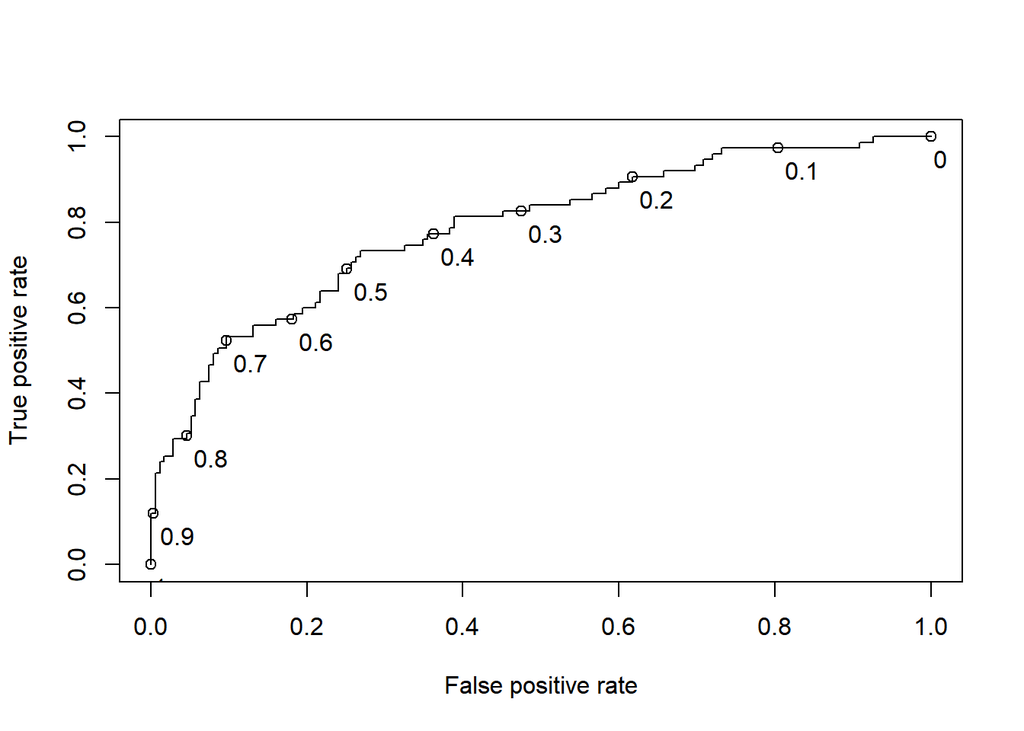

```r
ROCpred <- prediction(pred,Test_Creditnew$Default_)
ROCpref <- ROCR::performance(ROCpred,"tpr","fpr")
plot(ROCpref)
plot(ROCpref,colorsize=T,print.cutoffs.at=seq(0,1,0.1),text.adj=c(-0.2,1.7))
```

```r
library(pROC)
roc_obj <- roc(Test_Creditnew$Default_,pred)
auc = auc(roc_obj)
auc
```

```
## Area under the curve: 0.787
```

Area under the curve: 0.787 So,our model better has better predictive power

```r
Conc = Concordance(Test_Creditnew$Default_,pred)
Conc
```

```
## $Concordance
## [1] 0.7870476
##
## $Discordance
## [1] 0.2129524
##
## $Tied
## [1] 5.551115e-17
##
## $Pairs
## [1] 13125
```

```r
C = Conc$Concordance
D = Conc$Discordance
T = Conc$Tied
```

Interpretation:In 78% cases model is able to differentiate goods and bads correctly as it has to be.So ours model is a good model.

### Somers D

```r
D = (C-D)/(C+D)
D
```

```
## [1] 0.5740952
```

Interpretation: Somers d value is high, so we can say that out model has better predictive power

### Gain table

```r
#Step 1 - Create a data frame with two columns


actual = Test_Creditnew$Default_
newdata = data.frame(actual,pred1)
View(newdata)

#Step2 - Sort the data frame by the predicted probability
newdata = newdata[order(-newdata$pred1),]

#Step 3: Divide data into 10 equal parts

#how manyobservations should each group contain
nrow(newdata)/10
```

```
## [1] 25
```

```r
#Create the groups using index
groups = rep(1:10,each=floor(nrow(newdata)/10))
extra = rep(10,nrow(newdata)-length(groups))
groups = c(groups,extra)
groups
```

```
##   [1]  1  1  1  1  1  1  1  1  1  1  1  1  1  1  1  1  1  1  1  1  1  1  1  1  1
##  [26]  2  2  2  2  2  2  2  2  2  2  2  2  2  2  2  2  2  2  2  2  2  2  2  2  2
##  [51]  3  3  3  3  3  3  3  3  3  3  3  3  3  3  3  3  3  3  3  3  3  3  3  3  3
##  [76]  4  4  4  4  4  4  4  4  4  4  4  4  4  4  4  4  4  4  4  4  4  4  4  4  4
## [101]  5  5  5  5  5  5  5  5  5  5  5  5  5  5  5  5  5  5  5  5  5  5  5  5  5
## [126]  6  6  6  6  6  6  6  6  6  6  6  6  6  6  6  6  6  6  6  6  6  6  6  6  6
## [151]  7  7  7  7  7  7  7  7  7  7  7  7  7  7  7  7  7  7  7  7  7  7  7  7  7
## [176]  8  8  8  8  8  8  8  8  8  8  8  8  8  8  8  8  8  8  8  8  8  8  8  8  8
## [201]  9  9  9  9  9  9  9  9  9  9  9  9  9  9  9  9  9  9  9  9  9  9  9  9  9
## [226] 10 10 10 10 10 10 10 10 10 10 10 10 10 10 10 10 10 10 10 10 10 10 10 10 10
```

```r
#Attach the groups to the data
newdata$groups = groups
View(newdata)


#Creating a Gain table

library(sqldf)
gainTable = sqldf("select groups,count(actual) as N,sum(actual) as N1 from newdata group by groups")
class(gainTable)
```

```
## [1] "data.frame"
```

```r
View(gainTable)

#caluclate the cummulative sum of bads (or 1's)
gainTable$cumN1=cumsum(gainTable$N1)

#caluclate the cummulative percentage of bads (or 1's)
gainTable$Gain = round(gainTable$cumN1/sum(gainTable$N1)*100,3)

#Calulclate cummulative fit
gainTable$Lift = round(gainTable$Gain/((1:10)*10),3)

#print gain table
gainTable
```

```
##    groups  N N1 cumN1    Gain  Lift
## 1       1 25 13    13  17.333 1.733
## 2       2 25 15    28  37.333 1.867
## 3       3 25 14    42  56.000 1.867
## 4       4 25  9    51  68.000 1.700
## 5       5 25  2    53  70.667 1.413
## 6       6 25  8    61  81.333 1.356
## 7       7 25  3    64  85.333 1.219
## 8       8 25  5    69  92.000 1.150
## 9       9 25  1    70  93.333 1.037
## 10     10 25  5    75 100.000 1.000
```

### Gain Chart

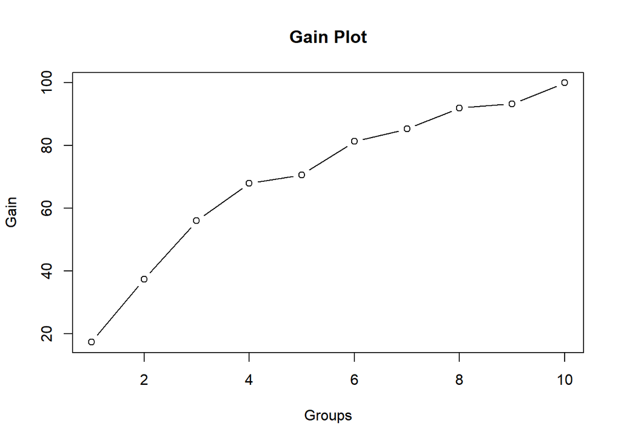

```r
plot(gainTable$groups, gainTable$Gain, type="b",
     main = "Gain Plot",
     xlab = "Groups", ylab = "Gain")
```

### Lift chart

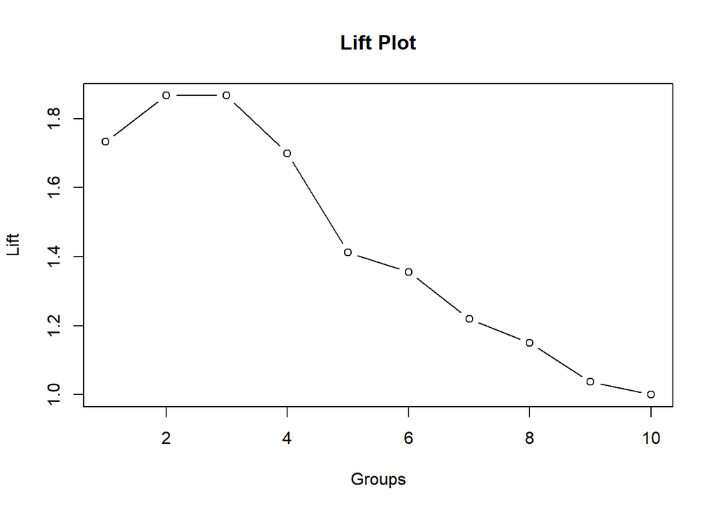

```r
plot(gainTable$groups, gainTable$Lift, type="b",
     main = "Lift Plot",
     xlab = "Groups", ylab = "Lift")
```

Interpretation:

The number of defaulters found in the first 4 groups as suggested by the model, is 1.7 times more than the number of defaulters that we will find if the data was randomly chosen.

### KS

```r
ks = sqldf("select groups, count(actual) as N, sum(actual) as N1,
           count(actual)-sum(actual) as N0 from newdata group by groups ")

View(ks)


#Calculate Percentage Events and Non-Events
ks$PerN0 = round(ks$N0/sum(ks$N0)*100,2)
ks$perN1 = round(ks$N1/sum(ks$N1)*100,2)


#Calculate Cumulative Percentage of Events and Non-Events
ks$CumPerN0 = cumsum(ks$PerN0)
ks$CumPerN1 = cumsum(ks$perN1)


#Calculation of KS
ks$KS = abs(ks$CumPerN0 - ks$CumPerN1)


#Print the Table
ks
```

```
##    groups  N N1 N0 PerN0 perN1 CumPerN0 CumPerN1    KS
## 1       1 25 13 12  6.86 17.33     6.86    17.33 10.47
## 2       2 25 15 10  5.71 20.00    12.57    37.33 24.76
## 3       3 25 14 11  6.29 18.67    18.86    56.00 37.14
## 4       4 25  9 16  9.14 12.00    28.00    68.00 40.00
## 5       5 25  2 23 13.14  2.67    41.14    70.67 29.53
## 6       6 25  8 17  9.71 10.67    50.85    81.34 30.49
## 7       7 25  3 22 12.57  4.00    63.42    85.34 21.92
## 8       8 25  5 20 11.43  6.67    74.85    92.01 17.16
## 9       9 25  1 24 13.71  1.33    88.56    93.34  4.78
## 10     10 25  5 20 11.43  6.67    99.99   100.01  0.02
```

### KS plot

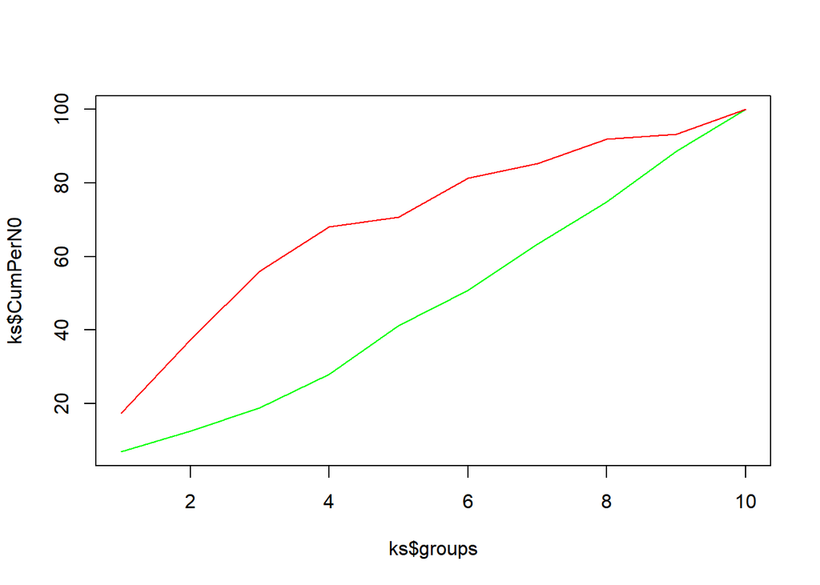

```r
plot(ks$groups, ks$CumPerN0, type="l", col = "Green")
lines(ks$groups, ks$CumPerN1, col = "Red")
```

### KS Static

```r
ks_stat(newdata$actual,newdata$pred1)
```

```
## [1] 0.4
```

Interpretation: The plot shows us that how well our model can distinguish between defaulters and non-defaulters. 0.4 is the maximum difference between the cumulative percentage of predicting defaulters and non-defaulters. Our model is predicting comparatively better than a random model

### Gini index

```r
gini = (2*auc)-1
gini
```

```
## [1] 0.5740952
```

By gini index,we can say that ours is a good model

### Conclusion:

A logistic regression model is applied to the credit dataset using the following features:installment,checkingstatus,duration,history,savings,age,property,purpose after determining the important variables, to make prediction of default status in the validation dataset.

Accuracy is 72.8% and AUC score of the ROC curve is 0.78